# Nguyen_Stephanie_final_project

Stephanie Nguyen

2022-11-18

#### Step #1: Set global options and load packages

#### Step #2: Import water use data; clean data

**Data Sources: Data on Country GDP are available from [The World Bank](https://data.worldbank.org/indicator/ny.gdp.pcap.cd?end=2021&start=2000) (2000-2020).** **Data on country water access are avaliable from UNICEF (2000-2020).**

```r
#Read data for country by continents
continent <- gapminder |>                                                       #Load gapminder, gapminder is an R library
  clean_names() |>                                                              #Clean column names
  select(c(country_name = "country", "continent")) |>                           #Select wanted columns
  distinct(.keep_all = TRUE)  |>                                                #Keep non-repeating columns
  add_row(country_name = "Moldova", continent = "Europe") |>                    #Add missing country
  add_row(country_name = "Virgin Islands (U.S.)", continent = "Americas") |>    #Add missing country
  add_row(country_name = "Laos", continent = "Asia") |>                         #Add missing country
  add_row(country_name = "Kyrgyzstan", continent = "Asia") |>                   #Add missing country
  add_row(country_name = "United Arab Emirates", continent = "Asia") |>         #Add missing country
  add_row(country_name = "Vanuatu", continent = "Oceania") |>                   #Add missing country
  add_row(country_name = "Uzbekistan", continent = "Asia") |>                   #Add missing country
  add_row(country_name = "Ukraine", continent = "Europe") |>                    #Add missing country
  add_row(country_name = "Tajikistan", continent = "Asia") |>                   #Add missing country
  add_row(country_name = "Suriname", continent = "Americas") |>                 #Add missing country
  add_row(country_name = "Tuvalu", continent = "Oceania") |>                    #Add missing country
  add_row(country_name = "Bahamas", continent = "Americas") |>                  #Add missing country
  add_row(country_name = "Turkmenistan", continent = "Asia") |>                 #Add missing country
  add_row(country_name = "Tonga", continent = "Oceania") |>                     #Add missing country
  add_row(country_name = "Timor-Leste", continent = "Asia") |>                  #Add missing country
  add_row(country_name = "South Sudan", continent = "Africa") |>                #Add missing country
  add_row(country_name = "Monaco", continent = "Europe") |>                     #Add missing country
  add_row(country_name = "Armenia", continent = "Asia") |>                      #Add missing country
  add_row(country_name = "Antigua and Barbuda", continent = "Americas") |>      #Add missing country
  add_row(country_name = "Russia", continent = "Europe") |>                     #Add missing country
  mutate(country_name = str_replace_all(country_name, c(                        #Rename countries for consistency
    "Congo, Rep." = "Congo",
    "Czech Republic" = "Czechia",
    "Korea, Rep." = "South Korea",
    "Hong Kong, China" = "Hong Kong",
    "Slovak Republic" = "Slovakia",
    "Swaziland" = "Eswatini",
    "Yemen, Rep." = "Yemen"
    ))) |>
  filter(!country_name %in% c("Korea, Dem. Rep.",                               #Filter out repeating columns
                              "Congo, Dem. Rep."))

#Read data for country GDP per capita
GDP <- read_excel(here("data/GDP_per_capita.xlsx")) |>                          #Load GDP per capita data
  clean_names() |>                                                              #Clean column names
  subset(select = -c(series_code, country_code, x2021_yr2021)) |>               #Take out unnecessary columns
  pivot_longer(cols = 3:23,                                                     #Pivot table longer for year column
               names_to = "year",
               values_to = "GDP_per_capita_USD") |>
  mutate(year = str_sub(year, start = 2, end = -8)) |>                          #Clean year labels
  mutate_at(vars(4),                                                            #Coerce data into numerics
            as.numeric,
            na.rm = TRUE) |>
  slice(1:4557) |>                                                              #Remove non-country rows
    mutate(country_name = str_replace_all(country_name, c(                      #Rename countries for consistency
    "Bahamas, The" = "Bahamas",
    "Congo, Dem. Rep." = "Congo",
    "Egypt, Arab Rep." = "Egypt",
    "Gambia, The" = "Gambia",
    "Hong Kong SAR, China" = "Hong Kong",
    "Korea, Rep." = "South Korea",
    "Iran, Islamic Rep." = "Iran",
    "Lao PDR" = "Laos",
    "Kyrgyz Republic" = "Kyrgyzstan",
    "Russian Federation" = "Russia",
    "Slovak Republic" = "Slovakia",
    "Syrian Arab Republic" = "Syria",
    "Turkiye" = "Turkey",
    "Venezuela, RB" = "Venezuela",
    "Yemen, Rep." = "Yemen"
    ))) |>
  filter(!country_name %in% c("Korea, Dem. People's Rep."))                     #Remove repeating country

#Read data for country population
pop <- read_excel(here("data/world_pop.xlsx")) |>                               #Load population data
  clean_names() |>                                                              #Clean column names
  subset(select = -c(country_code, series_code)) |>                             #Take out unnecessary columns
  pivot_longer(cols = 3:23,                                                     #Pivot table longer for years column
               names_to = "year",
               values_to = "population") |>
  mutate(year = str_sub(year, start = 2, end = -8)) |>                          #Clean year labels
  mutate_at(vars(4),                                                            #Coerce data into numerics
            as.numeric,
            na.rm = TRUE) |>
  slice(1:5586) |>                                                              #Remove non-country rows
    mutate(country_name = str_replace_all(country_name, c(                      #Rename countries for consistency
    "Bahamas, The" = "Bahamas",
    "Congo, Dem. Rep." = "Congo",
    "Czech Republic" = "Czechia",
    "Egypt, Arab Rep." = "Egypt",
    "Gambia, The" = "Gambia",
    "Hong Kong SAR, China" = "Hong Kong",
    "Korea, Rep." = "South Korea",
    "Iran, Islamic Rep." = "Iran",
    "Lao PDR" = "Laos",
    "Kyrgyz Republic" = "Kyrgyzstan",
    "Russian Federation" = "Russia",
    "Slovak Republic" = "Slovakia",
    "Syrian Arab Republic" = "Syria",
    "Turkiye" = "Turkey",
    "Venezuela, RB" = "Venezuela",
    "Yemen, Rep." = "Yemen"
    ))) |>
  filter(!country_name %in% c("Korea, Dem. People's Rep."))                     #Remove repeating country


#Read data for country water access
water_access <- read_excel(here("data/drinking_water_access.xlsx")) |>          #Load water access data
  mutate_at(vars(5),                                                            #Coerce data into numeric
            as.numeric,
            na.rm = TRUE) |>
  clean_names() |>                                                              #Clean column names
  select(c(country_name = "geographic_area",                                    #Select relevant columns
           "indicator",
           year = "time_period",
           percentage_w_wa = "obs_value")) |>
  filter(indicator %in% c(                                                      #Define access to water
    "Proportion of population using at least basic drinking water services"
  )) |>
  slice(1:5363) |>                                                              #Remove non-country rows
  mutate(country_name = str_replace_all(country_name, c(                        #Rename countries for consistency
    "Democratic Republic of the Congo" = "Congo",
    "Viet Nam" = "Vietnam",
    "Democratic People's Republic of Korea" = "South Korea",
    "China, Hong Kong Special Administrative Region" = "Hong Kong",
    "Lao People's Democratic Republic" = "Laos",
    "Republic of Moldova" = "Moldova",
    "Russian Federation" = "Russia",
    "Syrian Arab Republic" = "Syria",
    "United Republic of Tanzania" = "Tanzania",
    "The Republic of Turkey" = "Turkey",
    "Venezuela (Bolivarian Republic of)" = "Venezuela",
    "Virgin Islands U.S." = "Virgin Islands (U.S.)")))
```

**Q1: What data are you using?** I will be using data on countries’ water access and countries’ GDP.

**Q2: Where are the data from?** The data on countries’ water access is from UNICEF, while the data on countries’ GDP and population are from The World Bank.

**Q4: What is the main point of each of your figures?** The main point of my first figure is to observe if and how water access correlates to country GDP.

**Q5: Why did you choose the data that you chose? Why did you choose the topic that you choose?** I chose data from UNICEF because it was readily available and easy to query. The UNICEF website had options for me to choose what definitions of “access to water” I wanted, as well as what countries and years I wanted data from. For data on countries’ wealth, I chose data from the World Bank because although other websites had data on countries’ GDP, The World Bank was the only one I found find that was not only downloadable onto Excel, but also had data on the countries’ GDP per capita throughout time. I chose this topic because I thought it would be interesting to see if GDP does correlate with improved water access, as people in nations often don’t gain access to the growing wealth of their countries.

**Q6: In what ways are you hoping this project challenges you?** I am hoping this project challenges me to improve my debugging, documentation interpretation, and Google searching skills when it comes to coding. I foresee challenges in meshing my two data tables, since they are formatted very differently. I also foresee challenges with making the animation and graph aesthetically appealing when there are so many variables to depict.

#### Step #3: Organize data for Plot 1: Drinking Water Access vs GDP per Capita

```r
#Find mismatched names that will affect inner join with data
mismatch_names <- full_join(pop, GDP, by = c("country_name", "year")) |>        #Full join pop and GDP
  select(-c("series_name.x", "series_name.y")) |>                               #Remove unnecessary columns
  full_join(water_access,
            by = c("year", "country_name")) |>                                  #Full join data with water_access
  select(-c("indicator")) |>                                                    #Remove unnecessary column
  full_join(continent,                                                          #Full join data with continent
            by = c("country_name")) |>
  filter(!grepl("income|dividend|Europe|IDA|Saint|Asia|East|Sint Maarten|union|French|Island|Region|Samoa|Bonaire|mall",  #Filter out rows containing common strings
                country_name)) |>
  filter(!country_name %in% c("Africa Western and Central",                     #Filter out specific strings
                              "Arab World",
                              "Andorra",
                              "Anguilla",
                              "Australia and New Zealand",
                              "Congo, Rep.",
                              "Euro area",
                              "Fragile and conflict affected situations",
                              "Guadeloupe",
                              "Heavily indebted poor countries (HIPC)",
                              "IBRD only",
                              "Landlocked developing countries (LLDCs)",
                              "Latin America & Caribbean",
                              "Latin America & the Caribbean",
                              "Latin America and Caribbean",
                              "Least developed countries: UN classification",
                              "Least developed countries",
                              "Martinique",
                              "Mayotte",
                              "Montserrat",
                              "Niue",
                              "North America",
                              "Not classified",
                              "Oceania excluding Australia and New Zealand",
                              "OECD members",
                              "Republic of Korea",
                              "San Marino",
                              "SDG regions - Global",
                              "Sub-Saharan Africa",
                              "World",
                              "Africa",
                              "Americas",
                              "Taiwan",
                              "Tokelau",
                              "Wallis and Futuna",
                              "West and Central Africa",
                              "West Bank and Gaza",
                              "Western Pacific"))

#Find countries with full data for every year 2000-2020
full_country_data <- mismatch_names |>                                          #Load mismatch_names
  na.omit() |>                                                                  #Omit rows with na
  mutate_at(vars(2),                                                            #Coerce year into integer
            as.integer,
            na.rm = TRUE) |>
  group_by(country_name) |>                                                     #Group by country name
  summarize_at(1, sum, na.rm = TRUE) |>                                         #Sum up years
  ungroup() |>                                                                  #Ungroup
  filter(!year < 42210)                                                         #Select countries with complete data for all years

final_df <- mismatch_names |>                                                   #Load mismatch_names
  inner_join(full_country_data,                                                 #Inner join with countries with full data
             by = "country_name") |>
  select(c(country_name,                                                        #Select relevant columns
           year = "year.x",
           population,
           GDP_per_capita_USD,
           percentage_w_wa,
           continent)) |>
  mutate_at(vars(3:5),                                                          #Coerce data into numerics
            as.numeric,
            na.rm = TRUE) |>
  mutate_at(vars(2),                                                            #Coerce year into integer
            as.integer,
            na.rm = TRUE)
```

#### Step #4: Plot timeseries ggplot

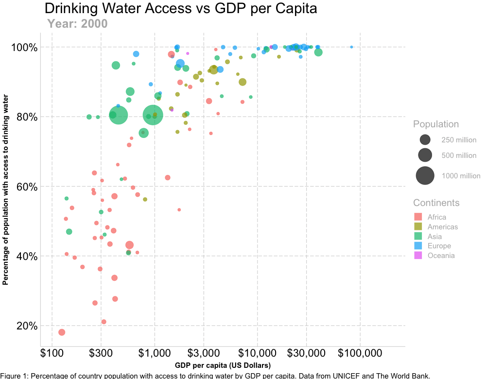

```r
final <- ggplot() +                                                             #Create ggplot

  geom_point(                                                                   #Create point plot
    data = final_df,                                                            #Load final_df
    aes(x = GDP_per_capita_USD,                                                 #Set aesthetics
    y = percentage_w_wa,
    size = population/1000000,                                                  #Turn point into bubble plot
    colour = continent),                                                        #Sort continents by color
    alpha = 0.7) +                                                              #Make bubbles opaque

  transition_time(year) +                                                       #Change data by years

  scale_size(                                                                   #Edit population legend
    range = c(2,20),                                                            #Set scale of bubble size
    name = "Population",                                                        #Rename population legend
    breaks = c(250, 500, 1000),                                                 #Change to 3 breaks
    labels = c("250 million", "500 million", "1000 million")) +                 #Add "million" to legend

  scale_colour_discrete(                                                        #Edit continent legend
    "Continents") +                                                             #Capitalize continents

  labs(                                                                         #Edit labels
       title = " Drinking Water Access vs GDP per Capita",                      #Add title
       subtitle = "          Year: {frame_time}",                               #Add subtitle
       x = "GDP per capita (US Dollars)",                                       #Label x axis
       y = "Percentage of population with access to drinking water",            #Label y axis
       fill = "",
       caption = "Figure 1: Percentage of country population with access to drinking water by GDP per capita. Data from UNICEF and The World Bank.") +

  theme_classic() +                                                             #Use classic theme

  theme(                                                                        #Edit plot theme
        plot.title = element_text(hjust = 0, size = 30),
        plot.caption = element_text(color = "black", hjust = -0.05,
                                    vjust = -1.3, size = 15),
        plot.caption.position = "plot",
        plot.subtitle = element_text(color = "gray71", hjust = -0.1,
                                     size = 25, face = "bold"),
        legend.position = "right",
        legend.title = element_text(color = "gray71", size = 20),
        legend.text = element_text(color = "gray71", size = 15),
        axis.text = element_text(color = "black", size = 22),
        axis.title.x = element_text(size = 15, vjust = -0.5, face = "bold"),
        axis.title.y = element_text(size = 15, face = "bold"),
        axis.ticks = element_blank(),
        axis.line = element_line(linetype = "solid", color = "lightgrey"),
        panel.grid.major = element_line(linetype = "longdash", color = "lightgrey")) +

  guides(color = guide_legend(override.aes = list(size = 7, shape = 15),        #Set size and shape of legend continent bubble
                              color = "lightgrey")) +

  scale_x_log10(                                                                #Make data more spread out via x axis
        breaks = c(100, 300, 1000, 3000, 10000, 30000, 100000),                 #Evenly space ticks
        labels = c("$100", "$300", "$1,000", "$3,000", "$10,000",               #Add $ and commas to axis label
                   "$30,000", "$100,000")) +

  scale_y_continuous(                                                           #Make continuous y axis
    breaks = c(20, 40, 60, 80, 100),
    labels = c("20%", "40%", "60%", "80%", "100%"))


animate(                                                                        #Create animation
        final, nframes = 90,                                                    #Set number of frames
        renderer = gifski_renderer("GDP_water_access.gif"),                     #Name gif
        height = 780, width = 1000)                                             #Set dimensions
```

**Q1: What is the take home message of this figure?** The take home message of this figure is that country GDP tends to be correlated with access to drinking water. The graph implies a positive relationship between country per capita wealth and the percentage of the population with drinking water.

**Q2: What is the most (or least) surprising?** The most surprising thing to me was the wealth gap between countries. Initially, without the log scale, I could barely tell what was going on in the data; all the poor countries were clustered on the y axis, while the richer countries were clustered at the top of the graph. Another surprising observation was how the country’s continent appears to be highly associated with its assess to drinking water. Even for countries of similar GDP’s, African countries tend to have less access to drinking water than its Asian or American equivalent.

**Q3: What three new functions did you implement to support visualization of the data? Explain what each of them does.** (1) I learned the scale_x_log10() function, which sets the x axis to a log scale instead of a continuous scale. This aided in the data visualization because the wealth gap between countries is so great that all the data would be clustered either on the y axis or the top of the graph if it was on a regular x axis. Thus, the log scale allows us to see the spread of the data better. (2) I also learned the animate() function, which allows you to make a gif of the plot, and the transition_time() function, that allowed me to animate the plot based on changing years, so you can see how countries’ access to drinking water and GDP change year by year. (3) In terms of data cleaning, the na.omit() function was useful in filtering out countries with missing data. If a country had missing data, it would appear and/or disappear at random points on the animation, so to avoid a visual confusing, I used na.omit() to take out countries with missing data. I also learned the distinct() function that allowed me to filter out repeating rows and the full_join() function that allowed me to join all the data together and see what rows had missing data at the bottom of the dataframe.